# geffaeR

Mathieu Genu

06/07/2020

[figure not shown]

## Introduction

When a lot of distance sampling campaign are made, analysis have to be done to estimate abundance with tools such as distance, dsm, kriging. But from a campaign to another, the objectives are not always the same, while the method remains the same.

Ex : For a particular campaign, we want a cds analysis for all the campaign but for species a and b. For the other campaign we want a cds analysis for each session of the campaign for species b and c. So there are specificities that will be managed by the user but the method can be set to be generic and put in a package, so we don’t have to modify the method for every campaign (illustrated fig1).

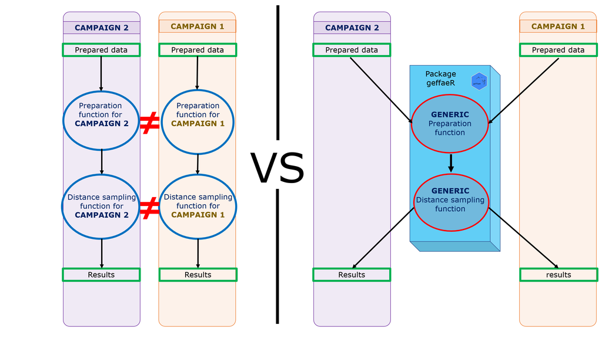

fig1 : Analysis of observation campaign before and after the creation of geffaeR

This package proposes functions to manipulate observation campaign for the estimation of abondance indexes by using several tools for different type of analysis, such as :

- CDS analysis (Coventional Distance Sampling) using Distance package (Distance)
- Kriging
- CDS analysis using Stan (rstan)
- DSM (Density Surface Modelling) using dsm package (dsm)